# KEGG Orthology Network Maker

fdelogu

28 januar, 2019

# KEGG Orthology Network Maker

## Getting started

### Set options and load libraries

```r
options(stringsAsFactors=F)
wd <- paste0(getwd(), "/")

library(tidyverse)
```

### Save KEGG urls

```r
rn.url <- "http://rest.kegg.jp/list/rn"
rnx.url <- "http://rest.kegg.jp/get/"
rn2rc.url <- "http://rest.kegg.jp/link/rc/rn"
ko2rn.url <- "http://rest.kegg.jp/link/rn/ko"
ko.json <- "https://www.genome.jp/kegg-bin/download_htext?htext=ko00001&format=json&filedir="
```

## The KEGG dataset

### The RN dataset

The reaction dataset (RN) lists all the reactions with their formulas. We will use the reaction codes listed in the KEGG dataset to start building the node set of the netowork. Download the RN dataset:

```r
if(!file.exists(paste0(wd, "data/rn.txt"))){
  print("Downloading the reaction list...")
  download.file(rn.url, paste0(wd, "data/rn.txt"))
} else {
  print("rn.txt is already present, check if it needs an update")
}
```

```
## [1] "rn.txt is already present, check if it needs an update"
```

Load the data into R:

```r
rn.list <- read.table(paste0(wd, "data/rn.txt"), header=F, sep="\t", quote="", fill=F)[,1]
length(rn.list)
```

```
## [1] 11106
```

### The RN-RC map

The reactions in KEGG are grouped into reaction classes ([RCs](https://www.genome.jp/kegg/reaction/)) which share “chemical structure transformation fatterns of substrate-product pairs”. Download the map between RN and RC:

```r
if(!file.exists(paste0(wd, "data/rn2rc.txt"))){
  print("Downloading the reaction to reaction class link...")
  download.file(rn2rc.url, paste0(wd, "data/rn2rc.txt"))
} else {
  print("rn2rc.txt is already present, check if it needs an update")
}
```

```
## [1] "rn2rc.txt is already present, check if it needs an update"
```

Load the map into R:

```r
rn2rc <- read.table(paste0(wd, "data/rn2rc.txt"), header=F, sep="\t", quote="", fill=F, col.names=c("RN", "RC"))
dim(rn2rc)
```

```
## [1] 16035     2
```

```r
head(rn2rc)
```

```
##          RN         RC
## 1 rn:R00106 rc:RC00001
## 2 rn:R00107 rc:RC00001
## 3 rn:R00108 rc:RC00001
## 4 rn:R00109 rc:RC00001
## 5 rn:R00111 rc:RC00001
## 6 rn:R00112 rc:RC00001
```

### Intersect RN and RC

If a reaction does not have a reaction class, it can be omitted. Thus, intersect the two datsets:

```r
rn.list.subset <- rn.list[rn.list%in%rn2rc$RN]
length(rn.list.subset)
```

```
## [1] 10149
```

### Compounds

All the reactions use reactants, called “Compounds” ([CPD](https://www.genome.jp/kegg/compound/)) in KEGG. We have to find the main reaction pair for each reaction. Thus download all the reactions from the previous intersection:

WARNING: This may require more than 1 hour. There is an extra courtesy time after each request to prevent KEGG to cut yout IP out. You may dicide to twich this time by tuning the parameters *m* and *s*, which ae the mean and standard deviation of the abs(normal distribution) to pick the waiting time from.

```r
m=0
s=0.2

sum(abs(rnorm(length(rn.list.subset), m, s)))/60 # Estimate of the waiting time (on top fo the actual download time)
```

```
## [1] 27.22407
```

```r
c=0
for(i in rn.list.subset){
  c=c+1
  if(!file.exists(paste0(wd, "data/reactions/", substr(i, 4, str_length(i)), ".txt"))){
    Sys.sleep(abs(rnorm(1, m, s))) # Decide if you want ot be nice with Kegg repo (you may be kicked out if you don't)
    download.file(paste0(rnx.url, i), paste0(wd, "data/reactions/", substr(i, 4, str_length(i)), ".txt"))
  }
  if(c%%1000==0){
    print(paste0(c, " out of ", length(rn.list.subset), " reactions checked"))
  }
}
```

```
## [1] "1000 out of 10149 reactions checked"
## [1] "2000 out of 10149 reactions checked"
## [1] "3000 out of 10149 reactions checked"
## [1] "4000 out of 10149 reactions checked"
## [1] "5000 out of 10149 reactions checked"
## [1] "6000 out of 10149 reactions checked"
## [1] "7000 out of 10149 reactions checked"
## [1] "8000 out of 10149 reactions checked"
## [1] "9000 out of 10149 reactions checked"
## [1] "10000 out of 10149 reactions checked"
```

### Cofators

The cofactors are compounds shared by many reactions without being their main reactants. In order to obrain a metabolic netowrk and improve the sparsity of it the cofactors must be removed. A list of cofator follows:

```r
cofactors <- c(
  "C00234", # 10-FORMYL-THF
  "C00024", # ACETYL-COA
  "C00008", # ADP
  "C00020", # AMP
  "C00002", # ATP
  "C00010", # CO-A
  "C00035", # GDP
  "C00064", # GLN - L-Glutamine
  "C00025", # GLT - L-Glutamate
  "C00044", # GTP
  "C00004", # NADH
  "C00005", # NADPH
  "C00006", # NADP
  "C00003", # NAD
  "C00074", # PHOSPHO-ENOL-PYRUVATE
  "C00100", # PROPIONYL-COA
  "C00022", # PYRUVATE
  "C00091", # SUC-COA
  "C00101", # THF
  "C00028", # Acceptor
  "C00126", # Cytochromes-C-Reduced
  "C00524", # Cytochromes-C
  "C00030", # Donor-H2
  "C03161", # Oxidized-flavodoxins
  "C03024" # Reduced-flavodoxins
)
```

Parse all the downloaded reactions and extract the compound from the *RCLASS* row. Exlude all the compounds that are also cofactors:

```r
if(!file.exists(paste0(wd, "data/rn2cpd_nocofactors.txt"))){
  rn2cpd <- data.frame(RN="", CPD="")
  for(i in rn.list.subset){
    parsed.rn <- unlist(str_split(read_file(paste0(wd, "data/reactions/", substr(i, 4, str_length(i)), ".txt")), "\n"))
    line.rc <- parsed.rn[which(grepl("RCLASS", parsed.rn)):
                         (min(which(grepl("ENZYME", parsed.rn)),
                             which(grepl("PATHWAY", parsed.rn)),
                             which(grepl("MODULE", parsed.rn)),
                             which(grepl("ORTHOLOGY", parsed.rn)),
                             which(grepl("DBLINKS", parsed.rn)),
                             which(grepl("///", parsed.rn)))-1)]
    if(!identical(line.rc, character(0))){
      split.rc <- unlist(str_split(line.rc, "\\s+"))
      parsed.rc <- unlist(str_split(unlist(split.rc[grepl("C[0-9]{5}_C[0-9]{5}", split.rc)]), "_"))
      #unlist(str_split(split.rc[3:(length(split.rc))], "_"))
      no.cofactor <- sort(parsed.rc[unlist(lapply(list(parsed.rc), function(x) ifelse(x%in%cofactors, F, T)))])
      if(!identical(no.cofactor, character(0))){
        rn2cpd <- rbind(rn2cpd, c(i, paste0(no.cofactor, collapse=";")))
      }
    }
  }
  rn2cpd <- rn2cpd[-1,]
  write.table(rn2cpd, file=paste0(wd, "data/rn2cpd_nocofactors.txt"), col.names=T, row.names=F, quote=F)
} else {
  rn2cpd <- read.table(paste0(wd, "data/rn2cpd_nocofactors.txt"), header=T)
}

dim(rn2cpd)
```

```
## [1] 10046     2
```

```r
head(rn2cpd)
```

```
##          RN           CPD
## 1 rn:R00005 C00011;C01010
## 2 rn:R00006        C00900
## 3 rn:R00008 C06033;C06033
## 4 rn:R00009 C00007;C00027
## 5 rn:R00010 C00031;C01083
## 6 rn:R00012        C01261
```

## Nodes of the network

### Kegg Orthology

The nodes will be a form of KEGG Orthology entries ([KOs](https://www.genome.jp/kegg/ko.html)), so we need to interface the reactions with the KOs. Downlaod the RN KO map:

```r
if(!file.exists(paste0(wd, "data/ko2rn.txt"))){
  print("Downloading the ko to reaction link...")
  download.file(ko2rn.url, paste0(wd, "data/ko2rn.txt"))
} else {
  print("ko2rn.txt is already present, check if it needs an update")
}
```

```
## [1] "ko2rn.txt is already present, check if it needs an update"
```

Load the map into R:

```r
ko2rn <- read.table(paste0(wd, "data/ko2rn.txt"), header=F, sep="\t", quote="", fill=F, col.names=c("KO", "RN"))
dim(ko2rn)
```

```
## [1] 10494     2
```

```r
head(ko2rn)
```

```
##          KO        RN
## 1 ko:K00001 rn:R00623
## 2 ko:K00001 rn:R00754
## 3 ko:K00001 rn:R02124
## 4 ko:K00001 rn:R04805
## 5 ko:K00001 rn:R04880
## 6 ko:K00001 rn:R05233
```

### Collapsed KEGG Ortholgy

Several KOs may have the same compounds, making them equivalent and redundant in this analysis. Therefore we collapse them into single entries.

First of all prepare some utility functions to map two data frames (*left* and *right*) which share a column name. The column with the same name will be intersected and used to extract all the combinantions of rows from *left* and *right* with the same key entry. The output is the concatenations of these rows.

```r
explosion <- function(df, col1, x){
  return(df[df[,col1]==x,])
}

concussion <- function(df1, df2, col1){

  df3 <- 1:(ncol(df1)+ncol(df2)-1)

  inter_inex <- unique(df1[,col1])[unique(df1[,col1])%in%unique(df2[,col1])]

  for(i in inter_inex){

    left_block <- as.data.frame(explosion(df1, col1, i))
    right_block <- as.data.frame(explosion(df2, col1, i)[,colnames(df2)[colnames(df2)!=col1]])

    for(j in 1:nrow(left_block)){
      for(z in 1:nrow(right_block)){
        df3 <- rbind(df3, t(c(unlist(left_block[j,]), unlist(right_block[z,]))))
      }
    }

  }

  colnames(df3) <- c(colnames(df1), colnames(df2)[colnames(df2)!=col1])


  return(as.data.frame(df3[-1,]))
}
```

Map KOs with the filtered RNs without cofactors:

```r
ko2cpd <- concussion(ko2rn, rn2cpd, "RN")
dim(ko2cpd)
```

```
## [1] 9806    3
```

```r
head(ko2cpd)
```

```
##            KO        RN           CPD
## X   ko:K00001 rn:R00623 C00071;C00226
## X.1 ko:K00121 rn:R00623 C00071;C00226
## X.2 ko:K04072 rn:R00623 C00071;C00226
## X.3 ko:K13951 rn:R00623 C00071;C00226
## X.4 ko:K13952 rn:R00623 C00071;C00226
## X.5 ko:K13953 rn:R00623 C00071;C00226
```

Finally collapse the KOs with the same CPDs and generate the Collapsed Kegg Orthology (CKO): our nodes.

```r
tmp <- unique(ko2cpd$CPD)
cpd2cko <- data.frame(CPD=tmp, CKO=paste0("CKO", 1:length(tmp)))

ko2cko <- concussion(ko2cpd, cpd2cko, "CPD")

rm(tmp)

write.table(ko2cko, file=paste0(wd, "results/ko2cko.txt"), col.names=T, row.names=F, quote=F)

dim(ko2cko)
```

```
## [1] 9806    4
```

```r
head(ko2cko)
```

```
##            KO        RN           CPD  CKO
## X   ko:K00001 rn:R00623 C00071;C00226 CKO1
## X.1 ko:K00121 rn:R00623 C00071;C00226 CKO1
## X.2 ko:K04072 rn:R00623 C00071;C00226 CKO1
## X.3 ko:K13951 rn:R00623 C00071;C00226 CKO1
## X.4 ko:K13952 rn:R00623 C00071;C00226 CKO1
## X.5 ko:K13953 rn:R00623 C00071;C00226 CKO1
```

## Edges of the network

### CKO-CPD network

All the nodes (CKOs) that share at least a CPD are linked by an edge. Multiple CPDs does not stack beacuse the network is binary (0 and 1 edge vaules allowed only). Compute the network:

```r
check_CPDs <- function(x, y){
  x <- unlist(str_split(x, ";"))
  y <- unlist(str_split(y, ";"))
  return(ifelse(sum((x%in%y)+0)>0, 1, 0))
}

if(!file.exists(paste0(wd, "results/CKO_Adj.txt"))){
  adj <- matrix(rep(0, nrow(cpd2cko)**2), nrow=nrow(cpd2cko))
  colnames(adj) <- cpd2cko$CKO
  rownames(adj) <- cpd2cko$CKO

  for(i in 1:(nrow(cpd2cko)-1)){
    for(j in (i+1):nrow(cpd2cko)){
      adj[cpd2cko$CKO[i],cpd2cko$CKO[j]] <- check_CPDs(cpd2cko$CPD[i],cpd2cko$CPD[j])
    }
  }

  adj[lower.tri(adj)] = t(adj)[lower.tri(adj)]
  write.table(adj, paste0(wd, "results/CKO_Adj.txt"), quote=F)
} else {
  adj <- data.matrix(read.table(paste0(wd, "results/CKO_Adj.txt")))
}
```

### Adjaceny matrix checks

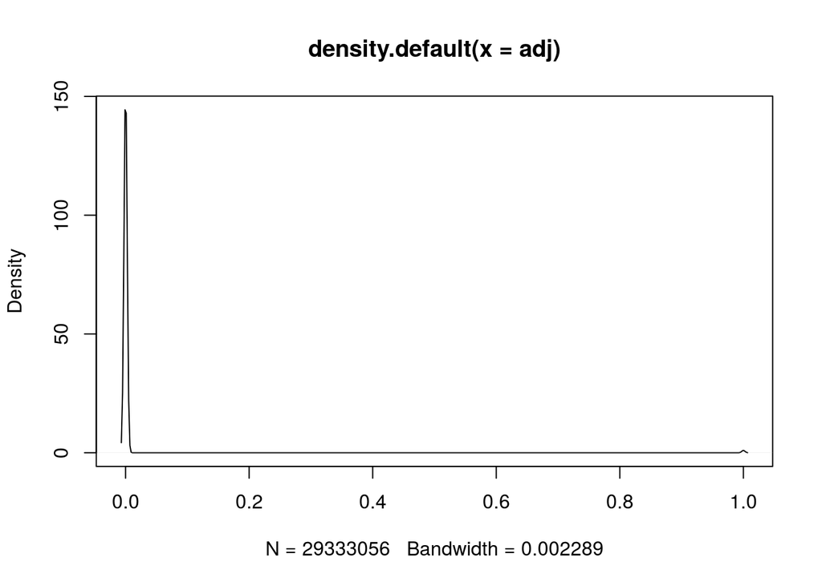

```r
plot(density(adj))
```

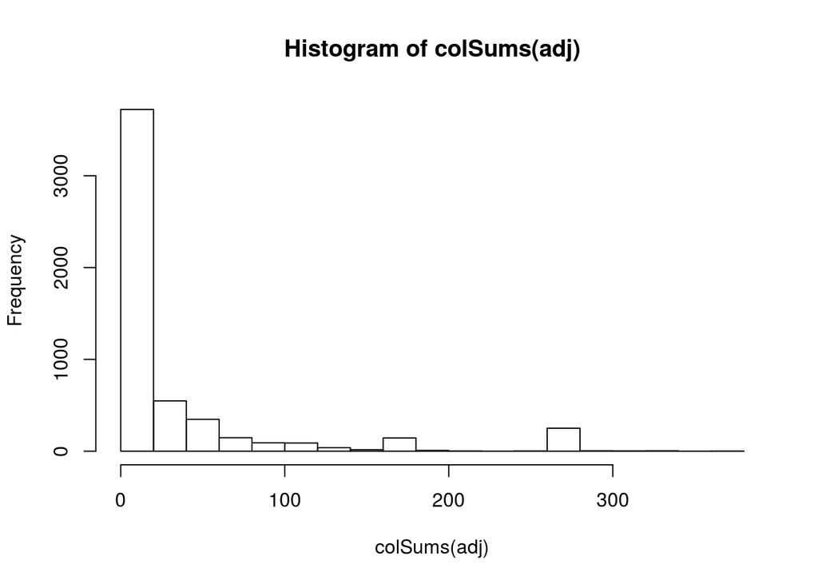

```r
hist(colSums(adj))
```